# Estudios de Informática, Multimedia y Telecomunicaciones

### 6.1.2 S’analitzen, mostren i comenten les mesures de qualitat del model generat.

- El cost del transport
- Distancia al lloc de treball
- Edad
- Educació
- Bebedor social
- BMI

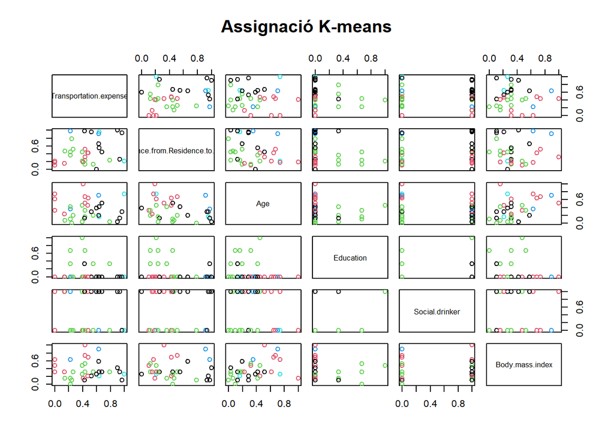

```r
# Mostre l'assignació real i la del k-means
x <- Abs_Norm[sig30]
plot(x, col = kmeans_1$cluster, main="Assignació K-means")
```

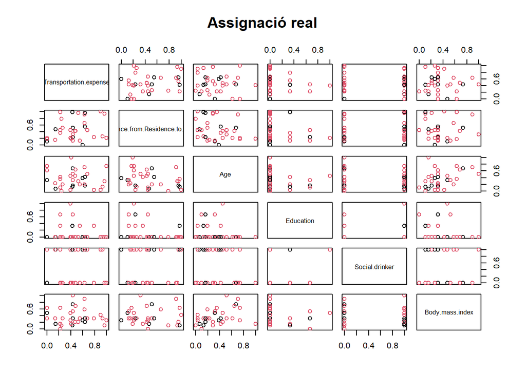

```r
plot(x, col = as.factor(AbsentismeFinal$Absenteeism.time.in.hours), main="Assignació real")
```

Una vegada mostrades les columnes principals, procedisc a mostrar la qualitat del model generat:

```r
print(kmeans_1)
```

```
## K-means clustering with 5 clusters of sizes 129, 145, 166, 106, 87
##
## Cluster means:
##   Month.of.absence Transportation.expense Distance.from.Residence.to.Work
## 1        0.4438002              1.2243803                      0.64886630
## 2        0.1344765             -0.7394030                     -0.94520756
## 3        0.1373539             -0.0452806                     -0.52983778
## 4       -0.1757867             -0.5588650                      1.38328395
## 5       -0.9300768              0.1841913                     -0.06119178
##          Age  Education        Son Work.load.Average.day Social.drinker
## 1 -0.2715246 -0.3686289  1.0837848            -0.3447174      0.8662780
## 2  1.0167114 -0.4469579 -0.1857641            -0.2200006     -0.2079699
## 3 -0.7632892  1.1443613 -0.2478305            -0.2397741     -0.9969267
## 4  0.3491462 -0.4469579 -0.8950071            -0.3404339      0.8372227
## 5 -0.2609191 -0.3474068  0.2659561             1.7500819     -0.0557472
```

[output cut: 81 more lines]

### 6.1.3 Es comenten les conclusions.

Com es pot veure a la suma dels quadrats per cluster, l’encert és d’un 46%. Es pot observar que no és molt bon ajust i que hi han dades no agrupades correctametn. Així i tot de l’anàlisi visual s’hi poden extraure les següents conclusions:

**El cost del transport:** S’hi pot veure que els treballadors que més gasten són els pitjors agrupats (molts no tenen grup). Sembla que s’han agrupat bé els que paguen poc i els que paguen d’intermig (els punts rojos i verds)

**Distancia al lloc de treball:** Comparant-ho amb la columna del cost de transport, s’hi veu que efectivament els treballadors que estan més a prop paguen menys. Una vegada més, les dades més elevades no s’han agrupat del tot correctament.

**Edat:** Comparant-ho amb les dues columnes anteriors, s’hi veu que els més joves viuen mitjanament més prop del lloc de treball, i que per tant gasten menys. Hi destaquen els punts rojos que semblen estar ben agrupats per edat, representant als majors.

**Educació:** A la columna d’educació s’hi veu que és on més difícil de llegir és. La gent amb poca educació formativa no es discerneix massa, però en canvi s’hi pot veure que la gent amb estudis sol ser gent jove amb vivenda pròxima al lloc de treball (punts verds)

**BMI:** En aquesta columna les dades són un poc més complicades de llegir. Principalment, s’hi veu en comparació amb els costos de transport, que els jovens (punts verds) ténen un BMI inferior a la mitja. Possiblement perquè siguen més actius o vagen al lloc de treball a peu. No ho podem saber, però si sabem que ells ténen menys despeses que la mitjana dels treballadors, a més d’un BMI relativament inferior.

Observant les dades, en general, s’hi pot intuïr que tal vegada un algorisme no supervisat basat en distàncies no donarà bons resultats en aquest dataset, ja que les dades no estan molt ben agrupades.

A banda de les conclusions observades a l’anàlisi visual, s’intueix que cal millorar el model per tenir un ajust més precís.